# Nigeria House Price Analysis

Lukman

2024-07-14

## Background

The prices of houses in Nigeria is known for its flunctuation overtime. This can be attributed to the loss in the value of the naira and some other factors. However, the aim of this analysis is to know how the prices of houses vary in different locations with respect to number of rooms and other inherent factors. This analysis will also help us establish how the prices of houses are affected by their inherent characteristics such as bedrooms and parking space.

## Preparation Of Data and Required Packages

The dataset to be used was extracted from data.world website. We will be loading the tidyverse package which is required for this analysis and also load the data using the read.csv function.

```r
library(tidyverse)
nigeria_houses <- read.csv('C:/Users/U/Desktop/DDP/nigeria_houses_data.csv')
```

Let’s have a glimpse of the data.

```r
glimpse(nigeria_houses)
```

```
## Rows: 24,326
## Columns: 8
## $ bedrooms      <dbl> 6, 4, 4, 4, 4, 5, 4, 2, 1, 4, 3, 6, 4, 4, 6, 3, 4, 3, 4,…
## $ bathrooms     <dbl> 5, 5, 5, 4, 4, 5, 5, 2, 1, 4, 4, 6, 5, 4, 6, 4, 4, 3, 5,…
## $ toilets       <dbl> 5, 5, 5, 5, 5, 6, 5, 3, 1, 5, 5, 6, 6, 5, 7, 4, 5, 4, 5,…
## $ parking_space <dbl> 4, 4, 4, 6, 2, 1, 4, 6, 1, 5, 4, 4, 3, 4, 4, 3, 4, 4, 4,…
## $ title         <chr> "Detached Duplex", "Terraced Duplexes", "Detached Duplex…
## $ town          <chr> "Mabushi", "Katampe", "Lekki", "Ajah", "Lekki", "Lekki",…
## $ state         <chr> "Abuja", "Abuja", "Lagos", "Lagos", "Lagos", "Lagos", "L…
## $ price         <dbl> 4.5e+08, 8.0e+08, 1.2e+08, 4.0e+07, 7.5e+07, 4.5e+08, 6.…
```

```r
head(nigeria_houses)
```

```
##   bedrooms bathrooms toilets parking_space                title    town state
## 1        6         5       5             4      Detached Duplex Mabushi Abuja
## 2        4         5       5             4    Terraced Duplexes Katampe Abuja
## 3        4         5       5             4      Detached Duplex   Lekki Lagos
## 4        4         4       5             6      Detached Duplex    Ajah Lagos
## 5        4         4       5             2 Semi Detached Duplex   Lekki Lagos
## 6        5         5       6             1      Detached Duplex   Lekki Lagos
##     price
## 1 4.5e+08
## 2 8.0e+08
## 3 1.2e+08
## 4 4.0e+07
## 5 7.5e+07
## 6 4.5e+08
```

The data is clean and processed so that means it can be relied on for our analysis.

## Analysis

### Average price for 3 bedroom flats across different states in Nigeria

```r
nigeria_houses %>%
  drop_na() %>%
  filter(bedrooms == 3) %>%
  group_by(state) %>%
  summarize(avg_price = mean(price)) %>%
  arrange(-avg_price)
```

```
## # A tibble: 19 × 2
##    state      avg_price
##    <chr>          <dbl>
##  1 Lagos     100907396.
##  2 Abia       92500000
##  3 Abuja      79076492.
##  4 Delta      71681818.
##  5 Anambara   67510811.
##  6 Rivers     63508929.
##  7 Imo        50768293.
##  8 Enugu      42052632.
##  9 Kogi       40000000
## 10 Edo        35285714.
## 11 Akwa Ibom  35214286.
## 12 Kano       30000000
## 13 Oyo        28907080.
## 14 Kwara      27500000
## 15 Ekiti      27333333.
## 16 Kaduna     27333333.
## 17 Nasarawa   21500000
## 18 Osun       20000000
## 19 Ogun       16669716.
```

### Towns with highest prices for 3 bedroom flats in Lagos

```r
nigeria_houses %>%
  drop_na() %>%
  filter(bedrooms == 3 & state == "Lagos") %>%
  group_by(town) %>%
  summarize(avg_price = mean(price)) %>%
  arrange(-avg_price)
```

```
## # A tibble: 44 × 2
##    town                  avg_price
##    <chr>                     <dbl>
##  1 Ikoyi                470073750
##  2 Apapa                335000000
##  3 Victoria Island (VI) 222848125
##  4 Maryland             190625000
##  5 Shomolu              175000000
##  6 Ajah                 136514857.
##  7 Ilupeju              136042857.
##  8 Lagos Island         132500000
##  9 Ijesha               120000000
## 10 Amuwo Odofin         116000000
## # ℹ 34 more rows
```

### Towns with the cheapest price for 3 bedroom flats in Lagos

```r
nigeria_houses %>%
  drop_na() %>%
  filter(bedrooms == 3 & state == "Lagos") %>%
  group_by(town) %>%
  summarize(avg_price = mean(price)) %>%
  arrange(avg_price)
```

```
## # A tibble: 44 × 2
##    town          avg_price
##    <chr>             <dbl>
##  1 Imota          6250000
##  2 Ijede         12000000
##  3 Ayobo         12900000
##  4 Agbara-Igbesa 15000000
##  5 Badagry       15000000
##  6 Epe           15000000
##  7 Ibeju         15000000
##  8 Ipaja         18375000
##  9 Agege         20157500
## 10 Ikorodu       20234146.
## # ℹ 34 more rows
```

### lowest to highest prices for 3 bedroom flats in Abuja

```r
nigeria_houses %>%
  drop_na() %>%
  filter(bedrooms == 3 & state == "Abuja") %>%
  group_by(town) %>%
  summarize(avg_price = mean(price)) %>%
  arrange(avg_price)
```

```
## # A tibble: 46 × 2
##    town       avg_price
##    <chr>          <dbl>
##  1 Gwagwalada  10500000
##  2 Kuje        13650000
##  3 Nyanya      14500000
##  4 Dei-Dei     17000000
##  5 Orozo       17000000
##  6 Kyami       18100000
##  7 Karshi      21250000
##  8 Bwari       24000000
##  9 Dakibiyu    27500000
## 10 Kurudu      27625000
## # ℹ 36 more rows
```

### highest to lowest prices for 3 bedroom flats in Abuja

```r
nigeria_houses %>%
  drop_na() %>%
  filter(bedrooms == 3 & state == "Abuja") %>%
  group_by(town) %>%
  summarize(avg_price = mean(price)) %>%
  arrange(-avg_price)
```

```
## # A tibble: 46 × 2
##    town              avg_price
##    <chr>                 <dbl>
##  1 Maitama District 619136475.
##  2 Katampe          441437500
##  3 Kado             420000000
##  4 Guzape District  418000000
##  5 Durumi           395000000
##  6 Garki            283571429.
##  7 Utako            191857143.
##  8 Asokoro District 179571429.
##  9 Jabi             151500000
## 10 Wuse             131666667.
## # ℹ 36 more rows
```

### Prices of 3 bedroom flats according to types or title

```r
nigeria_houses %>%
  drop_na() %>%
  filter(bedrooms == 3) %>%
  group_by(title) %>%
  summarize(avg_price = mean(price)) %>%
  arrange(-avg_price)
```

```
## # A tibble: 7 × 2
##   title                   avg_price
##   <chr>                       <dbl>
## 1 Semi Detached Duplex   334855769.
## 2 Block of Flats         135848434.
## 3 Detached Duplex         86381780.
## 4 Terraced Duplexes       60999557.
## 5 Detached Bungalow       41099525.
## 6 Terraced Bungalow       30242299.
## 7 Semi Detached Bungalow  24329454.
```

## Visualization

We will be using visualizations to show how the price of houses is affected by the different inherent characteristics such as bedroom and parking space.

### Relationship Between Number Of Toilet and Average Price Of Houses

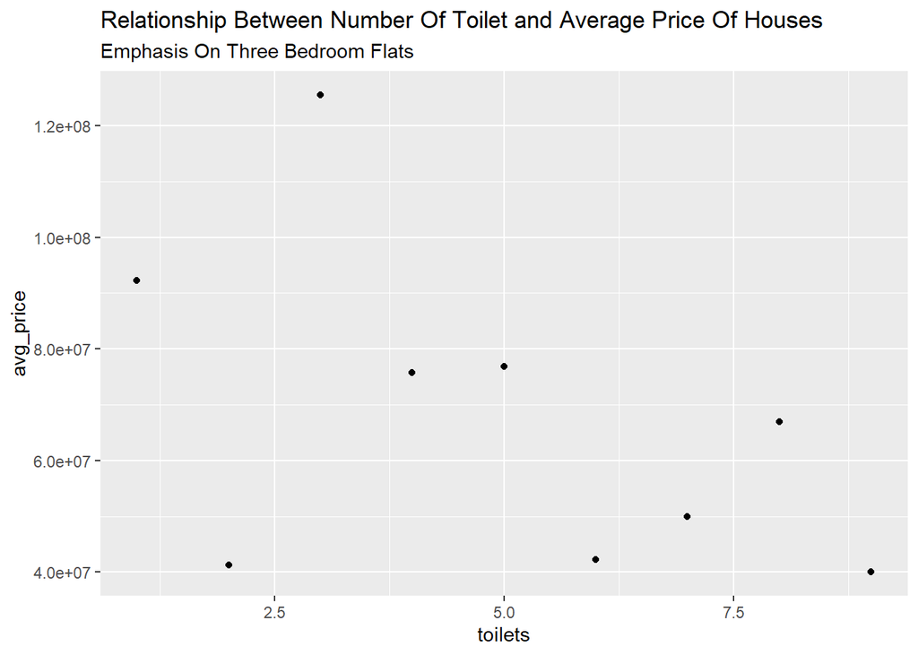

```r
nigeria_houses %>%
  drop_na() %>%
  filter(bedrooms == 3) %>%
  group_by(toilets) %>%
  summarize(avg_price = mean(price)) %>%
  ggplot(mapping = aes(x = toilets, y = avg_price))+
  geom_point()+
  labs(title = 'Relationship Between Number Of Toilet and Average Price Of Houses', subtitle = 'Emphasis On Three Bedroom Flats')
```

There isn’t much correlation going on there.

### Relationship Between Number Of Bathrooms and Average Price Of Houses

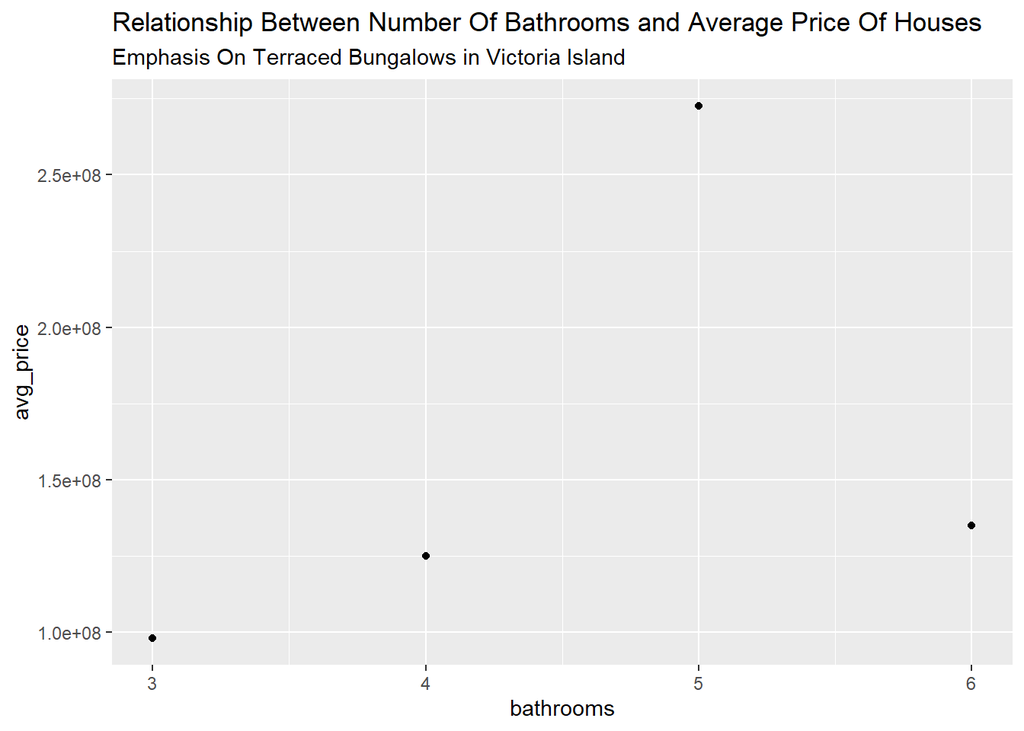

```r
nigeria_houses %>%
  drop_na() %>%
  filter(state == 'Lagos' & town == 'Victoria Island (VI)' & title == 'Terraced Bungalow') %>%
  group_by(bathrooms) %>%
  summarize(avg_price = mean(price)) %>%
  ggplot(mapping = aes(x = bathrooms, y = avg_price))+
  geom_point()+
  labs(title = 'Relationship Between Number Of Bathrooms and Average Price Of Houses', subtitle = 'Emphasis On Terraced Bungalows in Victoria Island')
```

The number of bathrooms also seems not to be a determining factor for the prices of houses.

### Relationship Between Number Of Parking Space and Average Price Of Houses

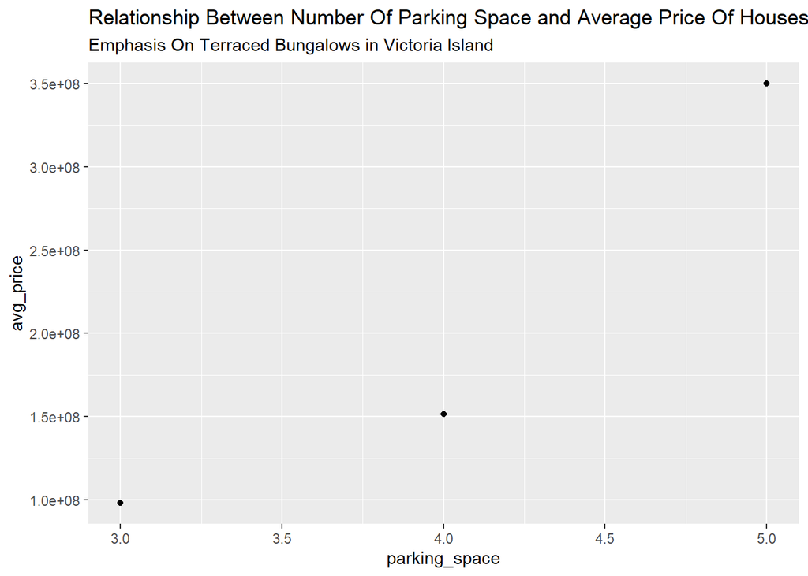

```r
nigeria_houses %>%
  drop_na() %>%
  filter(state == 'Lagos' & town == 'Victoria Island (VI)' & title == 'Terraced Bungalow') %>%
  group_by(parking_space) %>%
  summarize(avg_price = mean(price)) %>%
  ggplot(mapping = aes(x = parking_space, y = avg_price))+
  geom_point()+
  labs(title = 'Relationship Between Number Of Parking Space and Average Price Of Houses', subtitle = 'Emphasis On Terraced Bungalows in Victoria Island')
```

This shows some direct correlation.

### Relationship Between Number Of Bedrooms and Average Price Of Houses

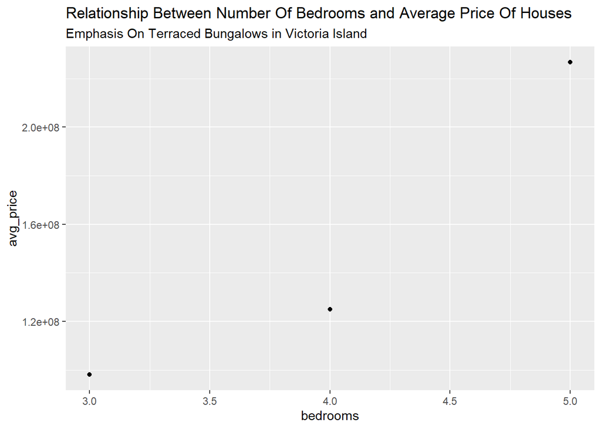

```r
nigeria_houses %>%
  drop_na() %>%
  filter(state == 'Lagos' & town == 'Victoria Island (VI)' & title == 'Terraced Bungalow') %>%
  group_by(bedrooms) %>%
  summarize(avg_price = mean(price)) %>%
  ggplot(mapping = aes(x = bedrooms, y = avg_price))+
  geom_point()+
  labs(title = 'Relationship Between Number Of Bedrooms and Average Price Of Houses', subtitle = 'Emphasis On Terraced Bungalows in Victoria Island')
```

### Conclusion

- The prices of houses are not really determined by the number of bathrooms or toilets but by the number of bedrooms and parking space available.
- The five most expensive states to buy a house in Nigeria are Lagos, Abia, Abuja, Delta and Anambra.
- The most expensive place to buy a house in Lagos is Ikoyi while the cheapest place is Imota.
- Gwagwalada is the cheapest place to buy a house in Abuja and the most expensive houses are in Maitama.
- The most expensive houses in Nigeria are semi detached duplex while the cheapest are semi detached bungalows.